# Progetto Statistica Inferenziale

## 5.5 Cranio

Prima di analizziare le potenziali differenze per la variabile **Cranio** tra i due sessi, creo un boxplot per la variabile *Cranio* condizionata alla variabile *Sesso* ed estrapolo le statistiche di sintesi con la funzione `summary()`, per le neonate F (`[df$Sesso=="F"]`) e per i neonati M (`[df$Sesso=="M"]`).

```r
summary(df$Cranio[df$Sesso=="F"])
```

```
##    Min. 1st Qu.  Median    Mean 3rd Qu.    Max.
##   235.0   330.0   340.0   337.6   348.2   390.0
```

```r
summary(df$Cranio[df$Sesso=="M"])
```

```
##    Min. 1st Qu.  Median    Mean 3rd Qu.    Max.
##   265.0   334.0   343.0   342.4   352.0   390.0
```

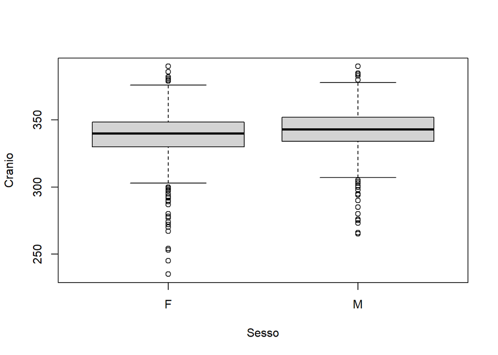

```r
boxplot(Cranio~Sesso, data = df)
```

Saggiamo la normale distribuzione dei dati:

```r
shapiro.test(Cranio)
```

```
##
##  Shapiro-Wilk normality test
##
## data:  Cranio
## W = 0.96357, p-value < 2.2e-16
```

Come già visto in precedenza la variabile *Cranio* contenuta nel dataset non si distribuisce normalmente.

Proviamo ad effettuare uno `shapiro.test()` raggruppando il datatset per la variabile *Sesso.*

```r
df %>%
  group_by(Sesso)%>%
  shapiro_test(Cranio)
```

```
## # A tibble: 2 x 4
##   Sesso variable statistic        p
##   <fct> <chr>        <dbl>    <dbl>
## 1 F     Cranio       0.955 4.12e-19
## 2 M     Cranio       0.970 3.01e-15
```

Anche qui il *p-value* è < di 0.05, pertanto i dati non si distribuiscono normalmente.

Saggiamo l’uguaglianza delle *varianze* tra i gruppi:

```r
var_cranio.sesso<-var.test(Cranio~Sesso,
                              data = df,
                              alternative = "two.sided")
var_cranio.sesso
```

```
##
##  F test to compare two variances
##
## data:  Cranio by Sesso
## F = 1.1301, num df = 1255, denom df = 1243, p-value = 0.03073
## alternative hypothesis: true ratio of variances is not equal to 1
## 95 percent confidence interval:
##  1.011431 1.262764
## sample estimates:
## ratio of variances
##           1.130149
```

Visualizzo graficamente il risultato del `var.test()`

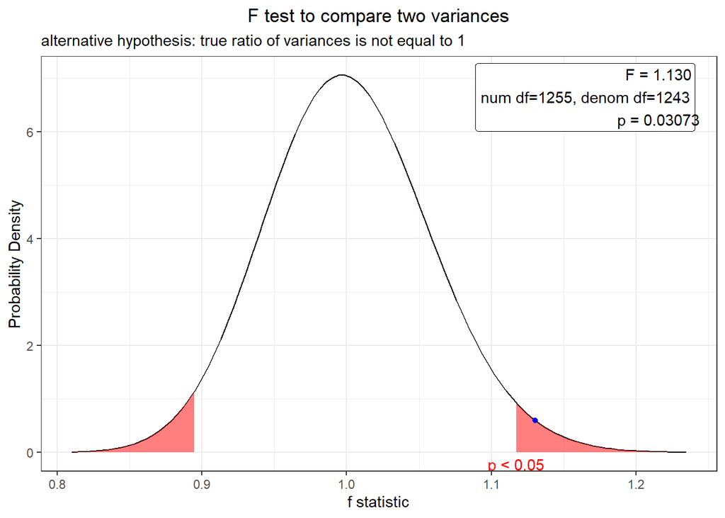

```r
plot(var_cranio.sesso)
```

**T di Student**

```r
tCranioSesso <- t.test(data = df,
                       Cranio~Sesso)
tCranioSesso
```

```
##
##  Welch Two Sample t-test
##
## data:  Cranio by Sesso
## t = -7.4102, df = 2491.4, p-value = 1.718e-13
## alternative hypothesis: true difference in means between group F and group M is not equal to 0
## 95 percent confidence interval:
##  -6.089912 -3.541270
## sample estimates:
## mean in group F mean in group M
##        337.6330        342.4486
```

Di seguito l’esito del t-test, rappresentato graficamente:

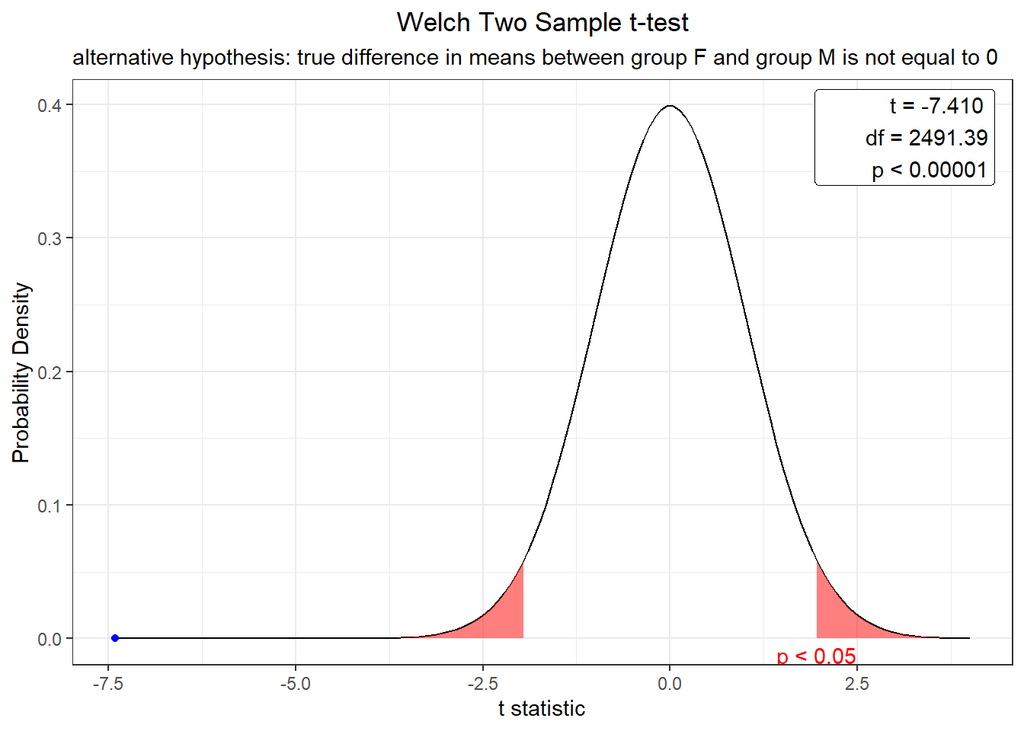

```r
plot(tCranioSesso)
```

**Wilcox Test**

```r
wilcoxTestCranioSesso <- wilcox.test(df$Cranio~df$Sesso,
                                     conf.level = 0.95,
                                     alternative = "two.sided",
                                     p.adjust.methods = "bonferroni")
wilcoxTestCranioSesso
```

```
##
##  Wilcoxon rank sum test with continuity correction
##
## data:  df$Cranio by df$Sesso
## W = 641638, p-value = 9.633e-15
## alternative hypothesis: true location shift is not equal to 0
```

Anche qui per entrambi i test il livello di significatività (Alfa) che delimita le zone di rifiuto è fissato al 5% (nella funzione indicato con `conf.level = 0.95` ovvero 1-Alfa)

Entrambi i test restituiscono un **p-value < Alfa** pertanto **l’ipotesi nulla è rifiutata a favore dell’ipotesi alternativa.**

## 5.6 Numero di gravidanze

Prima di analizziare le potenziali differenze per la variabile **Numero di gravidanze** tra i due sessi, creo un boxplot per la variabile *Numero di gravidanze* condizionata alla variabile *Sesso* ed estrapolo le statistiche di sintesi con la funzione `summary()`

```r
summary(df$N.gravidanze[df$Sesso=="F"])
```

```
##    Min. 1st Qu.  Median    Mean 3rd Qu.    Max.
##  0.0000  0.0000  1.0000  0.9498  1.0000 10.0000
```

```r
summary(df$N.gravidanze[df$Sesso=="M"])
```

```
##    Min. 1st Qu.  Median    Mean 3rd Qu.    Max.
##   0.000   0.000   1.000   1.013   1.000  12.000
```

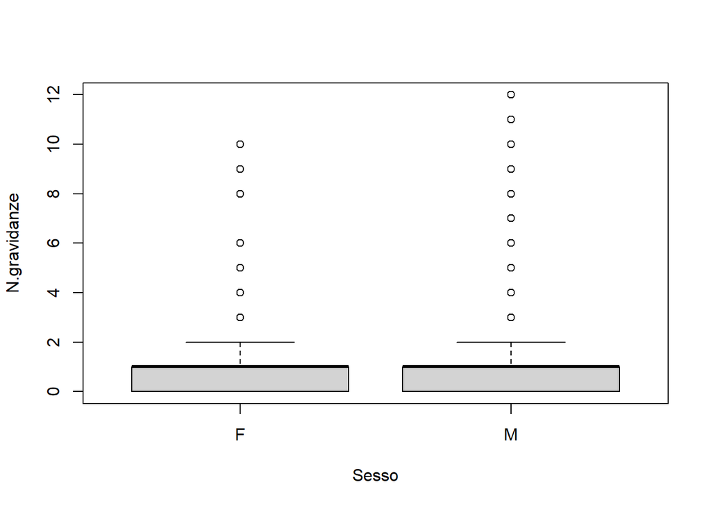

```r
boxplot(N.gravidanze~Sesso, data = df)
```

Saggiamo la normale distribuzione dei dati:

```r
shapiro.test(N.gravidanze)
```

```
##
##  Shapiro-Wilk normality test
##
## data:  N.gravidanze
## W = 0.72125, p-value < 2.2e-16
```

Come già visto in precedenza la variabile *N.gravidanze* contenuta nel dataset non si distribuisce normalmente.

Proviamo ad effettuare uno `shapiro.test()` raggruppando il datatset per la variabile *Sesso.*

```r
df %>%
  group_by(Sesso)%>%
  shapiro_test(N.gravidanze)
```

```
## # A tibble: 2 x 4
##   Sesso variable     statistic        p
##   <fct> <chr>            <dbl>    <dbl>
## 1 F     N.gravidanze     0.733 7.71e-41
## 2 M     N.gravidanze     0.711 8.10e-42
```

Anche qui il *p-value* è < di 0.05, pertanto i dati non si distribuiscono normalmente.

Saggiamo l’uguaglianza delle *varianze* tra i gruppi:

```r
var_gravidanze.sesso<-var.test(N.gravidanze~Sesso,
                           data = df,
                           alternative = "two.sided")
var_gravidanze.sesso
```

```
##
##  F test to compare two variances
##
## data:  N.gravidanze by Sesso
## F = 0.8469, num df = 1255, denom df = 1243, p-value = 0.003341
## alternative hypothesis: true ratio of variances is not equal to 1
## 95 percent confidence interval:
##  0.7579393 0.9462819
## sample estimates:
## ratio of variances
##          0.8469036
```

Visualizzo graficamente il risultato del `var.test()`

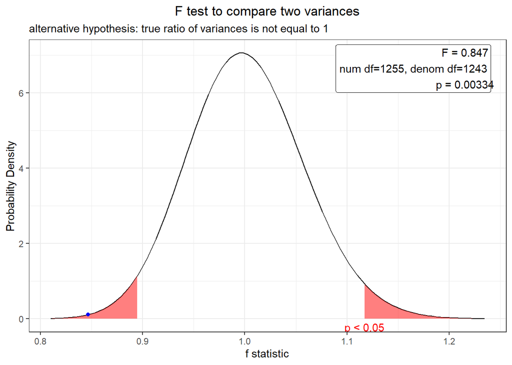

```r
plot(var_gravidanze.sesso)
```

**T di Student**

```r
tGravidanzeSesso <- t.test(data = df,
                       N.gravidanze~Sesso)
tGravidanzeSesso
```

```
##
##  Welch Two Sample t-test
##
## data:  N.gravidanze by Sesso
## t = -1.2299, df = 2476.8, p-value = 0.2188
## alternative hypothesis: true difference in means between group F and group M is not equal to 0
## 95 percent confidence interval:
##  -0.16349703  0.03745509
## sample estimates:
## mean in group F mean in group M
##       0.9498408       1.0128617
```

Di seguito l’esito del t test, rappresentato graficamente:

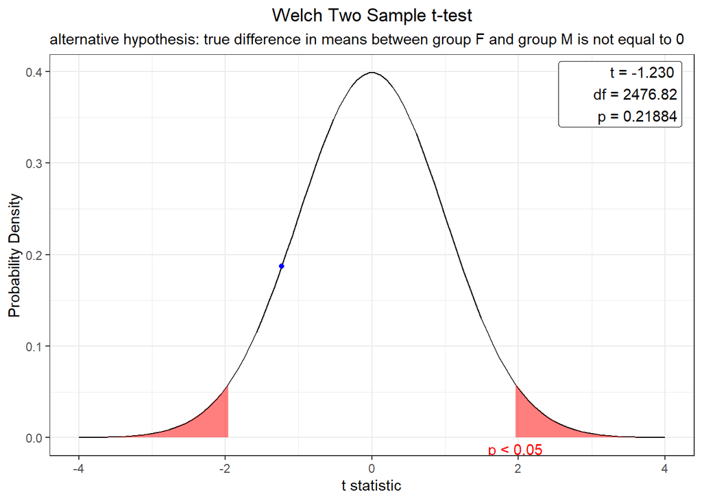

```r
plot(tGravidanzeSesso)
```

**Wilcox Test**

```r
wilcoxTestGravidanzeSesso <- wilcox.test(df$N.gravidanze~df$Sesso,
                                     conf.level = 0.95,
                                     alternative = "two.sided",
                                     p.adjust.methods = "bonferroni")
wilcoxTestGravidanzeSesso
```

```
##
##  Wilcoxon rank sum test with continuity correction
##
## data:  df$N.gravidanze by df$Sesso
## W = 763852, p-value = 0.304
## alternative hypothesis: true location shift is not equal to 0
```

Ricordo che in questo caso il nostro sistema di ipotesi è:

- H0: Media Numero di gravidanze F = Media Numero di gravidanze M
- H1: Media Numero di gravidanze F != Media Numero di gravidanze M

Anche qui per entrambi i test il livello di significatività (Alfa) che delimita le zone di rifiuto è fissato al 5% (nella funzione indicato con `conf.level = 0.95` ovvero 1-Alfa)

Entrambi i test restituiscono un **p-value > Alfa** pertanto **Non rifiutiamo l’ipotesi nulla.**

# 6 Verifica dell’ipotesi, secondo la quale, in alcuni ospedali si facciano più parti cesari

Utilizzando la libreria `dplyr` andrò ad estrapolare i dati riguardanti il numero di nascite e le tipologie di nascite, *Ces* e *Nat*, condizionatamente all’ospedale.

Di seguito il numero totale di nascite divise per Ospedale:

```r
partiTotali <- df%>%
  group_by(Ospedale)%>%
  count(Ospedale)
partiTotali
```

```
## # A tibble: 3 x 2
## # Groups:   Ospedale [3]
##   Ospedale     n
##   <fct>    <int>
## 1 osp1       816
## 2 osp2       849
## 3 osp3       835
```

Ora estrapolo i dati riguardanti alla tipologia di parto negli ospedali:

```r
partiCesEnat <- df%>%
  group_by(Ospedale, Tipo.parto)%>%
  count(Ospedale)
partiCesEnat
```

```
## # A tibble: 6 x 3
## # Groups:   Ospedale, Tipo.parto [6]
##   Ospedale Tipo.parto     n
##   <fct>    <fct>      <int>
## 1 osp1     Ces          242
## 2 osp1     Nat          574
## 3 osp2     Ces          254
## 4 osp2     Nat          595
## 5 osp3     Ces          232
## 6 osp3     Nat          603
```

Ora con i dati estrapolati andrò a creare una tabella, con la funzione `as.matrix()`, per poi saggiare l’ipotesi di indipendenza tra le variabili col **Test chi quadrato di Pearson**

```r
differenzeParti <- as.matrix(rbind(c(242,574),c(254,595),c(232,603)))
dimnames(differenzeParti) <- list(Ospedale = c("osp1", "osp2", "osp3"),
                                  Tipologia = c("Ces", "Nat"))
differenzeParti
```

```
##         Tipologia
## Ospedale Ces Nat
##     osp1 242 574
##     osp2 254 595
##     osp3 232 603
```

Visualizziamo graficamente la tabella, per farlo utilizzerò il pacchetto `ggpubr`:

```r
library(ggpubr)
```

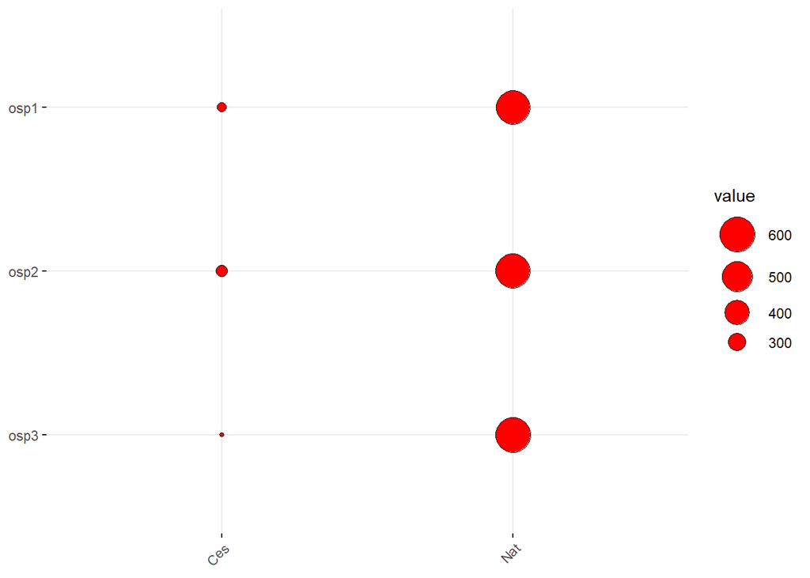

```r
ggpubr::ggballoonplot(data = as.data.frame(differenzeParti),
                      fill = "red")
```

**Test chi quadrato di Pearson**

```r
testTipoParto <- chisq.test(differenzeParti)
testTipoParto
```

```
##
##  Pearson's Chi-squared test
##
## data:  differenzeParti
## X-squared = 1.0972, df = 2, p-value = 0.5778
```

Visualizzo graficamente l’esito del test:

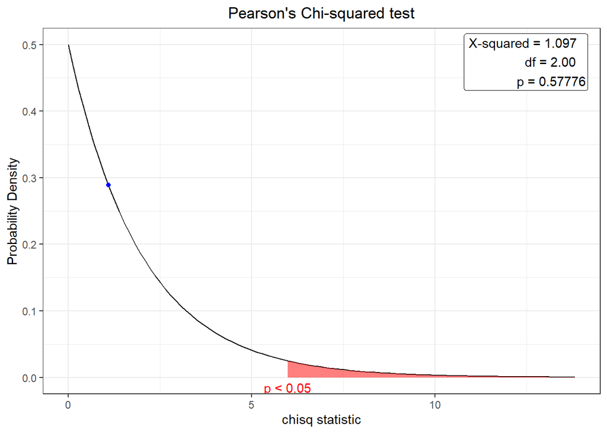

```r
plot(testTipoParto)
```

Ricordo che in questo caso il nostro sistema di ipotesi è:

**H0**: chi quadro = 0 (indipendenza tra le variabili)

**H1**: chi quadro > 0 (dipendenza tra le variabili, chi quadro < 0 impossibile)

Con il p-value > alpha **non si rifiuta l’ipotesi nulla**, le variabili sono tra loro indipendenti.

# 7 Ricordando qual è l’obiettivo dello studio, indago le relazioni a due a due, con la variabile risposta

**Covarianza**

In statistica la covarianza di due variabili statistiche o variabili aleatorie è un valore numerico che fornisce una misura di quanto le due varino assieme, ovvero della loro dipendenza. Fonte Wikipedia

Il valore numerico della covarianza può andare da *-infinito* a *+infinito*

- **Concordanza** per valori *positivi*
- **Discordanza** per valori *negativi*
- *Per valori di covarianza = 0* (o molto vicini allo 0) le **variabili sono indipendenti**

Per eliminare l’ambiguità dell’interpretazione dell’*indice della covarianza* (-infinito a +infinito) utilizzerò *l’indice di correlazione di Pearson*, funzione della covarianza, che restinge il campo di esistenza tra -1 e 1.

**Coefficiente di correlazione di lineare di Bravis-Pearson**

In statistica, l’indice di correlazione di Pearson tra due variabili statistiche è un indice che esprime un’eventuale relazione di linearità tra esse. [Fonte Wikipedia](https://it.wikipedia.org/wiki/Indice_di_correlazione_di_Pearson)

È un indice relativo simmetrico con valori che vanno da -1 e 1

- *indice di correlazione di Pearson* = 1 perfetta correlazione positiva
- *indice di correlazione di Pearson* = -1 perfetta correlazione negativa
- *indice di correlazione di Pearson* = 0 assenza di correlazione lineare

## 7.1 Gestione valori anomali

Prima di procedere eliminerò le osservazioni anomale rilevate nella variabile *Età della madre* che ricordo essere 0 ed 1 anno. Utilizzerò la libreria `dplyr` filtrando tutti i valori contenuti > di 2, ed assegnando tutti i dati in un nuovo dataframe.

```r
newDf <- df%>%
  filter(Anni.madre > 2)
```

Nel dataframe appena creato **newDf** *l’osservazione n°1549 risulta anomala*: il valore inserito nella variabile *Lunghezza* **non risulta coerente** se si osservano i valori contenuti nelle variabili *Peso*, *Cranio* e *Gestazione*. Ne terrò conto.

## 7.2 Relazione tra *Età della madre* e *Peso*

Per indagare la relazione tra le variabili calcolerò il *coefficiente di correlazione di lineare di Bravis-Pearson*, la cui funzione è `cor()` del pacchetto `stats`, e rappresenterò graficamente con uno *scatter plot*.

```r
cor(newDf$Anni.madre,newDf$Peso)
```

```
## [1] -0.02378138
```

L’indice di correlazione di Pearson è < 0 che indica **bassa correlazione lineare negativa**

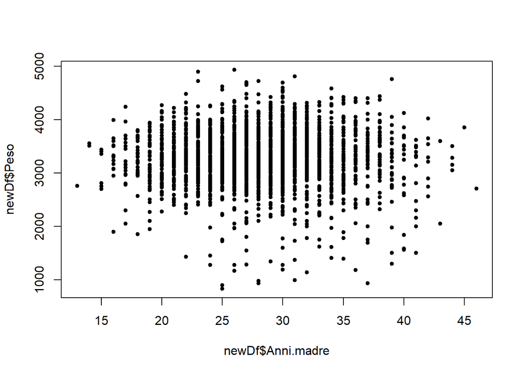

```r
plot(newDf$Anni.madre,newDf$Peso, pch = 20)
```

## 7.3 Relazione tra *Settimane di gestazione* e *Peso*

```r
cor(newDf$Gestazione,newDf$Peso)
```

```
## [1] 0.5919592
```

L’indice di correlazione di Pearson è > 0 che indica **media correlazione lineare positiva**

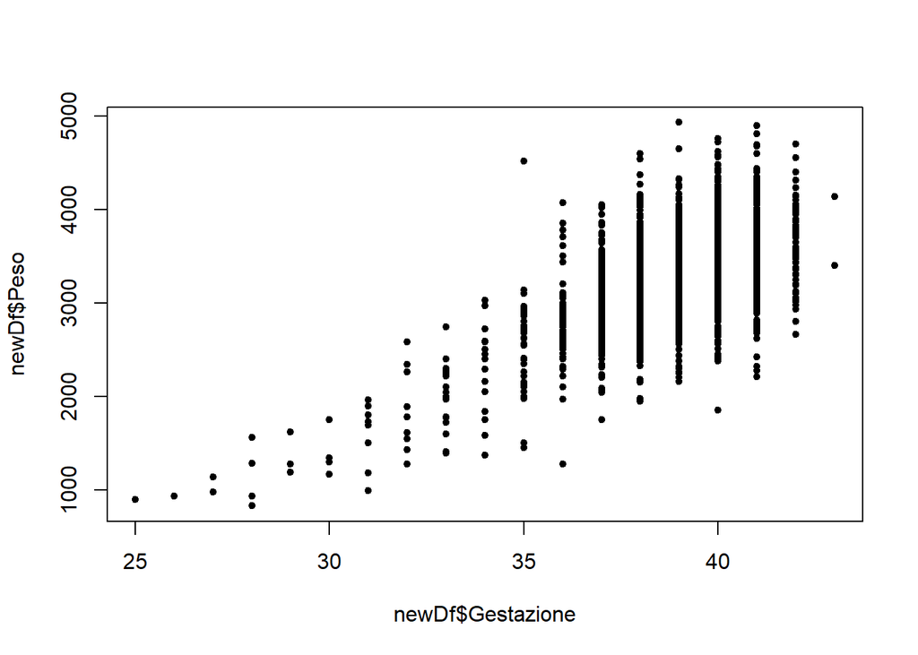

```r
plot(newDf$Gestazione,newDf$Peso, pch = 20)
```

## 7.4 Relazione tra *Lunghezza* e *Peso*

```r
cor(newDf$Lunghezza,newDf$Peso)
```

```
## [1] 0.7960415
```

L’indice di correlazione di Pearson è > 0 che indica **alta correlazione lineare positiva**

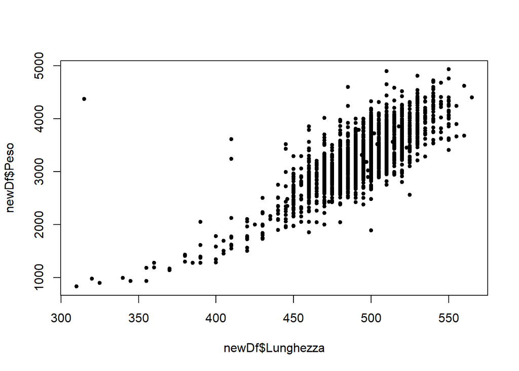

```r
plot(newDf$Lunghezza,newDf$Peso, pch = 20)
```

## 7.5 Relazione tra *Cranio* e *Peso*

```r
cor(newDf$Cranio,newDf$Peso)
```

```
## [1] 0.7048438
```

L’indice di correlazione di Pearson è > 0 che indica **alta correlazione lineare positiva**

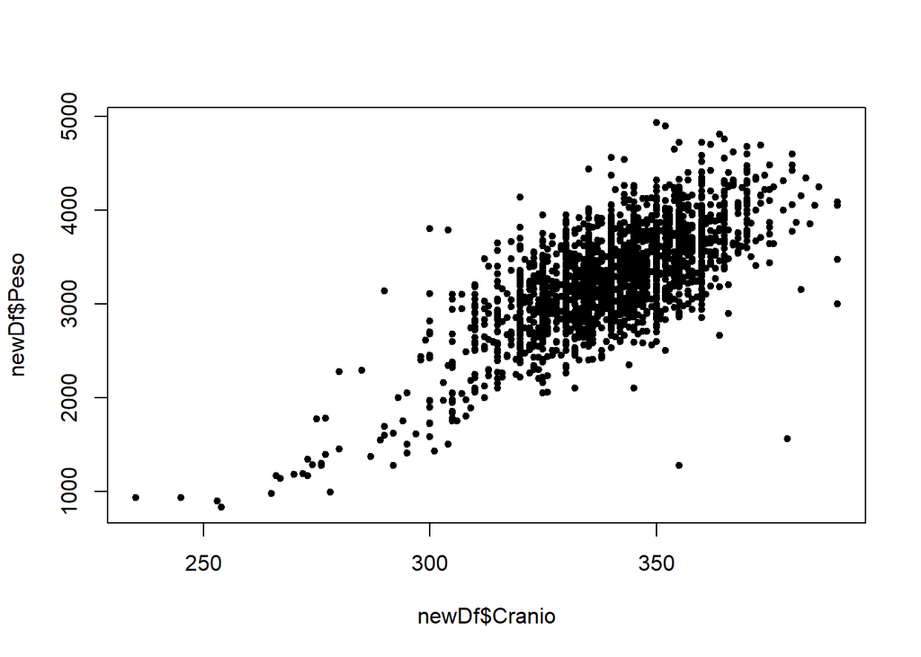

```r
plot(newDf$Cranio,newDf$Peso, pch = 20)
```

## 7.6 Trasposizione grafica della matrice di correlazione

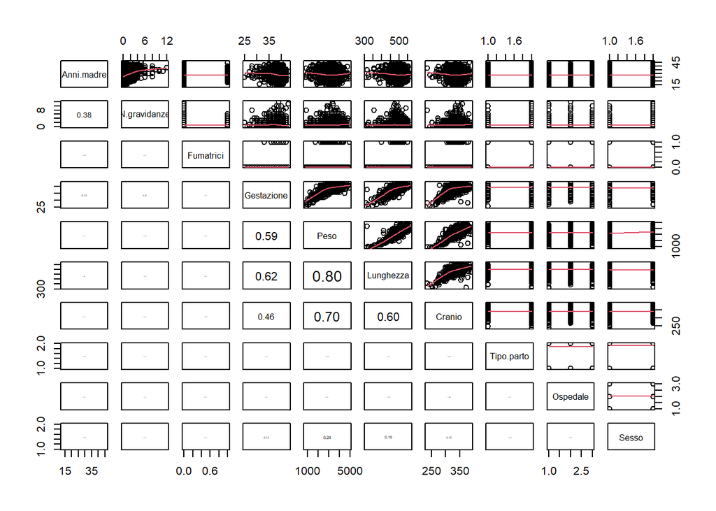

```r
panel.cor <- function(x, y, digits = 2, prefix = "", cex.cor, ...)
{
  usr <- par("usr"); on.exit(par(usr))
  par(usr = c(0, 1, 0, 1))
  r <- abs(cor(x, y))
  txt <- format(c(r, 0.123456789), digits = digits)[1]
  txt <- paste0(prefix, txt)
  if(missing(cex.cor)) cex.cor <- 0.8/strwidth(txt)
  text(0.5, 0.5, txt, cex = cex.cor * r)
}

pairs(newDf,
      upper.panel = panel.smooth,
      lower.panel = panel.cor )
```

**Nella diagonale** vengono mostrati i nomi delle variabili presenti nel dataframe.

**Sotto la diagonale** vengono mostrate le correlazioni per ogni coppia di varibili con grandezza del testo proporzionale alla correlazione rilevata.

**Sopra la diagonale** vengono mostrati gli scatter plot associati con la linea che indica la tendenza della nuvola di punti.

# 8 Crea un modello di regressione lineare multipla con tutte le variabili e commenta i coefficienti e il risultato ottenuto

## 8.1 Train e Test

Per prima cosa dividerò il dataframe in due, **Train**(80% delle osservazioni) e **Test**(20% delle osservazioni), per farlo utilizzerò la funzione `sample()` che estrarrà a caso le osservazioni da inserire nei dataframe Train e Test. Per la riproducibilità dei risultati utilizzerò `set.seed()`.

```r
set.seed(123)
trainIndex <- sample(x = 1:nrow(newDf),
                   replace = F,
                   size = 0.8*nrow(newDf))
train_df <- newDf[trainIndex, ]
test_df <- newDf[-trainIndex, ]
```

Come si evince dal blocco di codice sopra ho impostato il `set.seed(123)` così che i risultati siano riproducibili, a patto di utilizzare lo stesso seed (123).

`trainIndex` conterrà i valori presi a caso (`sample()`) di `x` che ho identificato da 1 alla lunghezza del dataframe (`x = 1:nrow(newDf)`), `replace = F` indica che le osservazioni possono essere prese una sola volta e con `size = 0.8*nrow(newDf)` ho indicato quante osservazioni prendere, 0.8 * numero di righe del dataframe, quindi l’ 80%.

Ho successivamente assegnato al nuovo dataframe `train_df` le osservazioni estratte precedentemente, mentre in `test_df` ho inserito tutte le osservazioni tranne quelle presenti in `train_df`, quindi il restante 20%.

## 8.2 Modello di regressione lineare multipla con tutte le variabili

Per stimare il modello utilizzerò la funzione `lm()`. La sintassi utilizzata `(Peso ~ ., data = train_df)` sta ad indicare che la variabile risposta è *Peso*, le variabili esplicative (regressori), indicate in forma contratta, verrannò tutte selezionate.

```r
mod1 <- lm(Peso ~ ., data = train_df)
```

## 8.3 Commenti sui coefficienti e risultato ottenuto

Di seguito le statistiche di sintesi del modello

```r
summary(mod1)
```

```
##
## Call:
## lm(formula = Peso ~ ., data = train_df)
##
## Residuals:
##      Min       1Q   Median       3Q      Max
## -1129.65  -182.09   -16.25   160.40  2567.11
##
## Coefficients:
##                 Estimate Std. Error t value Pr(>|t|)
## (Intercept)   -6781.9322   165.2893 -41.031  < 2e-16 ***
## Anni.madre        0.6986     1.2888   0.542   0.5878
## N.gravidanze     12.4236     5.1868   2.395   0.0167 *
## Fumatrici       -30.3658    30.1879  -1.006   0.3146
## Gestazione       32.9212     4.3633   7.545 6.84e-14 ***
## Lunghezza        10.1074     0.3344  30.228  < 2e-16 ***
## Cranio           10.8424     0.4772  22.722  < 2e-16 ***
## Tipo.partoNat    34.8101    13.5688   2.565   0.0104 *
## Ospedaleosp2    -10.5835    15.1525  -0.698   0.4850
## Ospedaleosp3     23.2579    15.1894   1.531   0.1259
## SessoM           86.6100    12.5756   6.887 7.61e-12 ***
## ---
## Signif. codes:  0 '***' 0.001 '**' 0.01 '*' 0.05 '.' 0.1 ' ' 1
##
## Residual standard error: 275.6 on 1987 degrees of freedom
## Multiple R-squared:  0.7174, Adjusted R-squared:  0.716
## F-statistic: 504.4 on 10 and 1987 DF,  p-value: < 2.2e-16
```

Guardando la tabella dei coefficienti `Coefficients:` al centro del `summary()` vengono mostrate le stime dei coefficienti di regressione Beta per tutte le variabili (colonna `Estimate`) che rappresentano gli effetti marginali di ogni singola variabile sulla variabile risposta. (Fonte Giuseppe Dejan Lucido)

Ad esempio: La variabile **Gestazione** ha un effetto positivo, di incremento, sul *Peso* (variabile risposta), nello specifico per ogni settimana di gestazione in più il peso del neonato aumenta di *32.9212 gr*. Questo effetto risulta essere molto significativo in quanto il p-value è di 6.84e-14, presente nella colonna `Pr(>|t|)`.

Il modello ha un `Adjusted R-squared: 0.716` che indica un modello molto buono. Esso serve a misurare la frazione di devianza spiegata, cioè la proporzione di variabilità di Y “spiegata” dalla variabile esplicativa X.[Fonte Wikipedia](https://it.wikipedia.org/wiki/Coefficiente_di_determinazione#Adjusted_R2)

# 9 Cerca il modello migliore, utilizzando tutti i criteri di selezione che conosci e spiegali

## 9.1 Procedura Stepwise

La procedura Stepwise consiste nel togliere e/o integrare (backward, forward, both) le variabili una per volta, valutando step by step i risultati ottenuti.

Per procedere potrei utilizzare la funzione `update()` che andrà ad aggiornare il modello esistente, ma procederò ad inserire le variabili esplicative in forma additiva.

### 9.1.1 mod2

```r
mod2 <- lm(Peso ~ N.gravidanze + Fumatrici + Gestazione + Lunghezza +
    Cranio + Tipo.parto + Ospedale + Sesso, data = train_df)
```

Di seguito le statistiche di sintesi del modello

```r
summary(mod2)
```

```
##
## Call:
## lm(formula = Peso ~ N.gravidanze + Fumatrici + Gestazione + Lunghezza +
##     Cranio + Tipo.parto + Ospedale + Sesso, data = train_df)
##
## Residuals:
##      Min       1Q   Median       3Q      Max
## -1121.36  -181.95   -16.59   160.11  2571.08
##
## Coefficients:
##                 Estimate Std. Error t value Pr(>|t|)
## (Intercept)   -6757.3715   158.9303 -42.518  < 2e-16 ***
## N.gravidanze     13.4179     4.8508   2.766  0.00572 **
## Fumatrici       -30.2605    30.1819  -1.003  0.31617
## Gestazione       32.6523     4.3342   7.534 7.45e-14 ***
## Lunghezza        10.1078     0.3343  30.235  < 2e-16 ***
## Cranio           10.8552     0.4765  22.780  < 2e-16 ***
## Tipo.partoNat    34.8397    13.5663   2.568  0.01030 *
## Ospedaleosp2    -10.5740    15.1498  -0.698  0.48528
## Ospedaleosp3     23.4522    15.1825   1.545  0.12258
## SessoM           86.6267    12.5733   6.890 7.47e-12 ***
## ---
## Signif. codes:  0 '***' 0.001 '**' 0.01 '*' 0.05 '.' 0.1 ' ' 1
##
## Residual standard error: 275.5 on 1988 degrees of freedom
## Multiple R-squared:  0.7174, Adjusted R-squared:  0.7161
## F-statistic: 560.6 on 9 and 1988 DF,  p-value: < 2.2e-16
```

### 9.1.2 mod3

Rimuovo la variabile esplicativa *Ospedale* che non risulta essere significativa.

```r
mod3 <- update(mod2,~. -Ospedale)
```

Di seguito le statistiche di sintesi del modello

```r
summary(mod3)
```

```
##
## Call:
## lm(formula = Peso ~ N.gravidanze + Fumatrici + Gestazione + Lunghezza +
##     Cranio + Tipo.parto + Sesso, data = train_df)
##
## Residuals:
##      Min       1Q   Median       3Q      Max
## -1135.19  -182.36   -16.14   161.44  2584.60
##
## Coefficients:
##                 Estimate Std. Error t value Pr(>|t|)
## (Intercept)   -6762.1731   158.9042 -42.555  < 2e-16 ***
## N.gravidanze     13.8173     4.8515   2.848  0.00444 **
## Fumatrici       -30.8643    30.2023  -1.022  0.30694
## Gestazione       33.0089     4.3349   7.615 4.06e-14 ***
## Lunghezza        10.0792     0.3343  30.152  < 2e-16 ***
## Cranio           10.8785     0.4768  22.815  < 2e-16 ***
## Tipo.partoNat    35.9106    13.5678   2.647  0.00819 **
## SessoM           87.2103    12.5813   6.932 5.60e-12 ***
## ---
## Signif. codes:  0 '***' 0.001 '**' 0.01 '*' 0.05 '.' 0.1 ' ' 1
##
## Residual standard error: 275.7 on 1990 degrees of freedom
## Multiple R-squared:  0.7166, Adjusted R-squared:  0.7156
## F-statistic: 718.8 on 7 and 1990 DF,  p-value: < 2.2e-16
```

Rimuovendo la variabile esplicativa *Ospedale* le stime (`Estimate`) delle altre variabili esplicative sono cambiate solo sensibilmente, e la significatività (`Pr(>|t|)`) è rimasta invariata, tranne che per la variabile *Tipo.partoNat* la cui significatività è aumentata. L’ `Adjusted R-squared: 0.7156` è leggermente diminuito.

### 9.1.3 mod4

Rimuovo la variabile esplicativa *Fumatrici* che non risulta essere significativa.

```r
mod4 <- update(mod3,~. -Fumatrici)
```

Di seguito le statistiche di sintesi del modello

```r
summary(mod4)
```

```
##
## Call:
## lm(formula = Peso ~ N.gravidanze + Gestazione + Lunghezza + Cranio +
##     Tipo.parto + Sesso, data = train_df)
##
## Residuals:
##      Min       1Q   Median       3Q      Max
## -1134.42  -182.60   -15.88   161.73  2588.05
##
## Coefficients:
##                 Estimate Std. Error t value Pr(>|t|)
## (Intercept)   -6763.3918   158.9015 -42.563  < 2e-16 ***
## N.gravidanze     13.5133     4.8425   2.791  0.00531 **
## Gestazione       32.7464     4.3274   7.567 5.79e-14 ***
## Lunghezza        10.0944     0.3339  30.227  < 2e-16 ***
## Cranio           10.8882     0.4767  22.840  < 2e-16 ***
## Tipo.partoNat    35.5568    13.5636   2.621  0.00882 **
## SessoM           86.8861    12.5775   6.908 6.59e-12 ***
## ---
## Signif. codes:  0 '***' 0.001 '**' 0.01 '*' 0.05 '.' 0.1 ' ' 1
##
## Residual standard error: 275.7 on 1991 degrees of freedom
## Multiple R-squared:  0.7164, Adjusted R-squared:  0.7156
## F-statistic: 838.4 on 6 and 1991 DF,  p-value: < 2.2e-16
```

Rimuovendo la variabile esplicativa *Fumatrici* le stime (`Estimate`) delle altre variabili esplicative sono cambiate solo sensibilmente, e la significatività (`Pr(>|t|)`) è rimasta invariata. L’ `Adjusted R-squared: 0.7156` è invariato.

### 9.1.4 mod9

Rimuovo la variabile esplicativa *Tipo.parto*.

```r
mod9 <- update(mod4,~. -Tipo.parto)
```

Di seguito le statistiche di sintesi del modello

```r
summary(mod9)
```

```
##
## Call:
## lm(formula = Peso ~ N.gravidanze + Gestazione + Lunghezza + Cranio +
##     Sesso, data = train_df)
##
## Residuals:
##      Min       1Q   Median       3Q      Max
## -1158.34  -185.21   -14.33   162.94  2592.43
##
## Coefficients:
##                Estimate Std. Error t value Pr(>|t|)
## (Intercept)  -6733.4474   158.7238 -42.422  < 2e-16 ***
## N.gravidanze    13.1875     4.8480   2.720  0.00658 **
## Gestazione      32.9000     4.3333   7.592  4.8e-14 ***
## Lunghezza       10.0622     0.3342  30.107  < 2e-16 ***
## Cranio          10.9039     0.4774  22.841  < 2e-16 ***
## SessoM          87.1229    12.5957   6.917  6.2e-12 ***
## ---
## Signif. codes:  0 '***' 0.001 '**' 0.01 '*' 0.05 '.' 0.1 ' ' 1
##
## Residual standard error: 276.2 on 1992 degrees of freedom
## Multiple R-squared:  0.7155, Adjusted R-squared:  0.7148
## F-statistic:  1002 on 5 and 1992 DF,  p-value: < 2.2e-16
```

# 10 Si potrebbero considerare interazioni o effetti non lineari?

## 10.1 Effetti non lineari

Dalla trasposizione grafica della matrice di correlazione presente al punto 7.6 ho notato un leggero effetto non lineare tra le variabili:

- Peso e Gestazione

### 10.1.1 mod5

Aggiungo questo effetto non lineare al modello:

```r
mod5 <- update(mod4,~. +I(Gestazione^2))
```

Di seguito le statistiche di sintesi del modello

```r
summary(mod5)
```

```
##
## Call:
## lm(formula = Peso ~ N.gravidanze + Gestazione + Lunghezza + Cranio +
##     Tipo.parto + Sesso + I(Gestazione^2), data = train_df)
##
## Residuals:
##      Min       1Q   Median       3Q      Max
## -1134.03  -182.88   -15.61   161.71  2589.98
##
## Coefficients:
##                   Estimate Std. Error t value Pr(>|t|)
## (Intercept)     -6577.4898  1163.1459  -5.655 1.78e-08 ***
## N.gravidanze       13.5008     4.8443   2.787  0.00537 **
## Gestazione         22.4997    63.6568   0.353  0.72379
## Lunghezza          10.1030     0.3383  29.866  < 2e-16 ***
## Cranio             10.8948     0.4786  22.763  < 2e-16 ***
## Tipo.partoNat      35.4859    13.5740   2.614  0.00901 **
## SessoM             86.7291    12.6181   6.873 8.36e-12 ***
## I(Gestazione^2)     0.1360     0.8431   0.161  0.87184
## ---
## Signif. codes:  0 '***' 0.001 '**' 0.01 '*' 0.05 '.' 0.1 ' ' 1
##
## Residual standard error: 275.8 on 1990 degrees of freedom
## Multiple R-squared:  0.7165, Adjusted R-squared:  0.7155
## F-statistic: 718.3 on 7 and 1990 DF,  p-value: < 2.2e-16
```

Aggiungendo l’effetto non lineare di *Gestazione^2* le stime (`Estimate`) delle altre variabili esplicative sono invariate,come anche la significatività (`Pr(>|t|)`). Per la variabile *Gestazione* la stima è variata sensibilmente e dal p-value in`Pr(>|t|)` vedo che la variabile non è più significativa. Lo stesso effetto non lineare implementato non è significativamente rilevante. L’ `Adjusted R-squared: 0.7155` è pressocchè invariato.

## 10.2 Interazione tra due variabili

Ora saggerò l’ipotesi che le variabili possano avere un effetto congiunto sulla variabile risposta, pertanto aggiungerò al modello l’effetto di interazione tra due variabili per volta.

- Cranio e Lunghezza
- Cranio e Gestazione
- Gestazione e Lunghezza

### 10.2.1 mod6

```r
mod6 <- lm(Peso ~ N.gravidanze + Gestazione + Lunghezza + Cranio +
             Tipo.parto + Sesso + Cranio:Lunghezza, data = train_df)
```

Di seguito le statistiche di sintesi del modello

```r
summary(mod6)
```

```
##
## Call:
## lm(formula = Peso ~ N.gravidanze + Gestazione + Lunghezza + Cranio +
##     Tipo.parto + Sesso + Cranio:Lunghezza, data = train_df)
##
## Residuals:
##     Min      1Q  Median      3Q     Max
## -1137.5  -185.5   -13.0   158.9  2765.1
##
## Coefficients:
##                    Estimate Std. Error t value Pr(>|t|)
## (Intercept)      -2.805e+03  1.200e+03  -2.337  0.01952 *
## N.gravidanze      1.378e+01  4.831e+00   2.853  0.00437 **
## Gestazione        3.671e+01  4.478e+00   8.198 4.32e-16 ***
## Lunghezza         1.581e+00  2.580e+00   0.613  0.54014
## Cranio           -1.399e+00  3.722e+00  -0.376  0.70709
## Tipo.partoNat     3.349e+01  1.354e+01   2.473  0.01349 *
## SessoM            8.367e+01  1.258e+01   6.650 3.78e-11 ***
## Lunghezza:Cranio  2.540e-02  7.633e-03   3.328  0.00089 ***
## ---
## Signif. codes:  0 '***' 0.001 '**' 0.01 '*' 0.05 '.' 0.1 ' ' 1
##
## Residual standard error: 275.1 on 1990 degrees of freedom
## Multiple R-squared:  0.718,  Adjusted R-squared:  0.717
## F-statistic: 723.9 on 7 and 1990 DF,  p-value: < 2.2e-16
```

Aggiungendo l’interazione tra le variabili *Lunghezza:Cranio* le stime (`Estimate`) delle altre variabili esplicative sono variate sensibilmente, come anche la significatività (`Pr(>|t|)`). Per le variabili *Lunghezza* e *Cranio* la stima è variata sensibilmente e dal p-value in`Pr(>|t|)` vedo che le variabile non sono più significative. L’interazione tra le variabili è significativamente rilevante ma con una stima che tende a 0. L’ `Adjusted R-squared: 0.717` è pressocchè invariato.

### 10.2.2 mod7

```r
mod7 <- lm(Peso ~ N.gravidanze + Gestazione + Lunghezza + Cranio +
             Tipo.parto + Sesso + Cranio:Gestazione, data = train_df)
```

Di seguito le statistiche di sintesi del modello

```r
summary(mod7)
```

```
##
## Call:
## lm(formula = Peso ~ N.gravidanze + Gestazione + Lunghezza + Cranio +
##     Tipo.parto + Sesso + Cranio:Gestazione, data = train_df)
##
## Residuals:
##      Min       1Q   Median       3Q      Max
## -1126.23  -182.14   -13.19   159.77  2633.78
##
## Coefficients:
##                    Estimate Std. Error t value Pr(>|t|)
## (Intercept)       -788.2549  1383.5402  -0.570 0.568920
## N.gravidanze        13.8431     4.8214   2.871 0.004133 **
## Gestazione        -125.9597    36.7606  -3.426 0.000624 ***
## Lunghezza           10.2663     0.3348  30.664  < 2e-16 ***
## Cranio              -7.6588     4.2927  -1.784 0.074553 .
## Tipo.partoNat       32.7800    13.5181   2.425 0.015401 *
## SessoM              82.4354    12.5631   6.562 6.76e-11 ***
## Gestazione:Cranio    0.4851     0.1116   4.347 1.45e-05 ***
## ---
## Signif. codes:  0 '***' 0.001 '**' 0.01 '*' 0.05 '.' 0.1 ' ' 1
##
## Residual standard error: 274.5 on 1990 degrees of freedom
## Multiple R-squared:  0.7191, Adjusted R-squared:  0.7181
## F-statistic: 727.8 on 7 and 1990 DF,  p-value: < 2.2e-16
```

### 10.2.3 mod8

```r
mod8 <- lm(Peso ~ N.gravidanze + Gestazione + Lunghezza + Cranio +
             Tipo.parto + Sesso + Gestazione:Lunghezza, data = train_df)
```

Di seguito le statistiche di sintesi del modello

```r
summary(mod8)
```

```
##
## Call:
## lm(formula = Peso ~ N.gravidanze + Gestazione + Lunghezza + Cranio +
##     Tipo.parto + Sesso + Gestazione:Lunghezza, data = train_df)
##
## Residuals:
##      Min       1Q   Median       3Q      Max
## -1139.67  -181.91   -13.46   160.84  2599.49
##
## Coefficients:
##                        Estimate Std. Error t value Pr(>|t|)
## (Intercept)          -2643.0952  1135.5953  -2.327 0.020039 *
## N.gravidanze            13.7489     4.8279   2.848 0.004447 **
## Gestazione             -77.6297    30.4306  -2.551 0.010815 *
## Lunghezza                1.1411     2.4661   0.463 0.643607
## Cranio                  11.0361     0.4769  23.139  < 2e-16 ***
## Tipo.partoNat           33.8443    13.5295   2.502 0.012446 *
## SessoM                  82.6551    12.5915   6.564 6.65e-11 ***
## Gestazione:Lunghezza     0.2363     0.0645   3.664 0.000255 ***
## ---
## Signif. codes:  0 '***' 0.001 '**' 0.01 '*' 0.05 '.' 0.1 ' ' 1
##
## Residual standard error: 274.9 on 1990 degrees of freedom
## Multiple R-squared:  0.7183, Adjusted R-squared:  0.7174
## F-statistic: 725.1 on 7 and 1990 DF,  p-value: < 2.2e-16
```

Aggiungendo l’interazione tra le variabili *Gestazione:Lunghezza* le stime (`Estimate`) delle altre variabili esplicative sono variate, come anche la significatività (`Pr(>|t|)`). Per le variabili *Gestazione* e *Lunghezza* la stima è variata sensibilmente, Gestazione ora ha negativo quindi decrementa la variabile risposta, dal p-value in`Pr(>|t|)` vedo che la variabile Lunghezza non è più significativa. L’interazione tra le variabili è significativamente rilevante ma con una stima che tende a 0. L’ `Adjusted R-squared: 0.7174` è pressocchè invariato.

## 10.3 Anova

L’anova è un test statistico che utilizzerò per capire se aggiungere o meno una variabile al modello. Questo test statistico rapporta le varianze spiegate dei due modelli e valuta se l’aumento o la diminuzione è stata significativa.

### 10.3.1 mod4 mod5

```r
anova(mod4, mod5)
```

```
## Analysis of Variance Table
##
## Model 1: Peso ~ N.gravidanze + Gestazione + Lunghezza + Cranio + Tipo.parto +
##     Sesso
## Model 2: Peso ~ N.gravidanze + Gestazione + Lunghezza + Cranio + Tipo.parto +
##     Sesso + I(Gestazione^2)
##   Res.Df       RSS Df Sum of Sq     F Pr(>F)
## 1   1991 151389780
## 2   1990 151387800  1    1980.3 0.026 0.8718
```

Nella tavola di analisi della varianza sopra calcolata vengono mostrati i due modelli confrontati, nella colonna `RSS` le varianze spiegate dai due modelli, e nella colonna `Pr(>F)` viene mostrato il p-value relativo al test **p-value 0.8718** che indica un aumento non significativo di varianza spiegata.

### 10.3.2 mod4 mod6

```r
anova(mod4, mod6)
```

```
## Analysis of Variance Table
##
## Model 1: Peso ~ N.gravidanze + Gestazione + Lunghezza + Cranio + Tipo.parto +
##     Sesso
## Model 2: Peso ~ N.gravidanze + Gestazione + Lunghezza + Cranio + Tipo.parto +
##     Sesso + Cranio:Lunghezza
##   Res.Df       RSS Df Sum of Sq      F    Pr(>F)
## 1   1991 151389780
## 2   1990 150551818  1    837962 11.076 0.0008904 ***
## ---
## Signif. codes:  0 '***' 0.001 '**' 0.01 '*' 0.05 '.' 0.1 ' ' 1
```

Nella tavola di analisi della varianza sopra calcolata vengono mostrati i due modelli confrontati, nella colonna `RSS` le varianze spiegate dai due modelli, e nella colonna `Pr(>F)` viene mostrato il p-value relativo al test **p-value 0.0008904** che indica un aumento significativo di varianza spiegata quando si aggiunge l’interazione.

### 10.3.3 mod4 mod7

```r
anova(mod4, mod7)
```

```
## Analysis of Variance Table
##
## Model 1: Peso ~ N.gravidanze + Gestazione + Lunghezza + Cranio + Tipo.parto +
##     Sesso
## Model 2: Peso ~ N.gravidanze + Gestazione + Lunghezza + Cranio + Tipo.parto +
##     Sesso + Cranio:Gestazione
##   Res.Df       RSS Df Sum of Sq      F    Pr(>F)
## 1   1991 151389780
## 2   1990 149965597  1   1424183 18.898 1.448e-05 ***
## ---
## Signif. codes:  0 '***' 0.001 '**' 0.01 '*' 0.05 '.' 0.1 ' ' 1
```

Nella tavola di analisi della varianza sopra calcolata vengono mostrati i due modelli confrontati, nella colonna `RSS` le varianze spiegate dai due modelli, e nella colonna `Pr(>F)` viene mostrato il p-value relativo al test **p-value 1.448e-05** che indica un aumento significativo di varianza spiegata quando si aggiunge l’interazione.

### 10.3.4 mod4 mod8

```r
anova(mod4, mod8)
```

```
## Analysis of Variance Table
##
## Model 1: Peso ~ N.gravidanze + Gestazione + Lunghezza + Cranio + Tipo.parto +
##     Sesso
## Model 2: Peso ~ N.gravidanze + Gestazione + Lunghezza + Cranio + Tipo.parto +
##     Sesso + Gestazione:Lunghezza
##   Res.Df       RSS Df Sum of Sq      F    Pr(>F)
## 1   1991 151389780
## 2   1990 150375245  1   1014535 13.426 0.0002547 ***
## ---
## Signif. codes:  0 '***' 0.001 '**' 0.01 '*' 0.05 '.' 0.1 ' ' 1
```

Nella tavola di analisi della varianza sopra calcolata vengono mostrati i due modelli confrontati, nella colonna `RSS` le varianze spiegate dai due modelli, e nella colonna `Pr(>F)` viene mostrato il p-value relativo al test **p-value 0.0002547** che indica un aumento significativo di varianza spiegata quando si aggiunge l’interazione.

## 10.4 AIC-BIC

Per essere sicuro sulla scelta del modello migliore utilizzerò altri criteri di valutazione:

-Il critero di informazione di Akaike

-Il critero di informazione Bayesiano

L’AIC può essere definito come una misura della bontà di adattamento di qualsiasi modello statistico stimato. Il BIC è un tipo di selezione del modello tra una classe di modelli parametrici con diversi numeri di parametri. Quando si confrontano i criteri di informazione bayesiana e i criteri di informazione di Akaike, la penalità per i parametri aggiuntivi è più in BIC che AIC. A differenza dell’AIC, il BIC penalizza maggiormente i parametri liberi. I Criteri di informazione di Akaike in genere cercano di trovare un modello sconosciuto che abbia una realtà ad alta dimensione. Ciò significa che i modelli non sono veri modelli in AIC. D’altra parte, i criteri di informazione bayesiana si riferiscono solo ai modelli reali. Si può anche dire che i criteri di informazione bayesiana sono coerenti mentre i criteri di informazione di Akaike non lo sono.[Fonte](https://it.sawakinome.com/articles/miscellaneous/unassigned-1740.html#:~:text=I%20Criteri%20di%20informazione%20di%20Akaike%20in%20genere%20cercano%20di,riferiscono%20solo%20ai%20modelli%20reali.)

Per utilizzare l’ AIC e il BIC come criterio di selezione del modello, bisogna confrontare il risultato di un modello con i risultati di altri modelli, in generale il modello con i criteri di informazione più bassi è di solito il modello migliore (Fonte Giuseppe Dejan Lucido).

*AIC*

```r
AIC(mod1,mod2,mod3,mod4,mod5,mod6,mod7,mod8,mod9)
```

```
##      df      AIC
## mod1 12 28135.83
## mod2 11 28134.12
## mod3  9 28135.49
## mod4  8 28134.54
## mod5  9 28136.51
## mod6  9 28125.45
## mod7  9 28117.66
## mod8  9 28123.11
## mod9  7 28139.42
```

Secondo il metodo di valutazione AIC il modello migliore risulta essere il *mod7*

*BIC*

```r
BIC(mod1,mod2,mod3,mod4,mod5,mod6,mod7,mod8,mod9)
```

```
##      df      BIC
## mod1 12 28203.02
## mod2 11 28195.72
## mod3  9 28185.89
## mod4  8 28179.34
## mod5  9 28186.91
## mod6  9 28175.85
## mod7  9 28168.05
## mod8  9 28173.50
## mod9  7 28178.62
```

Secondo il metodo di valutazione BIC il modello migliore risulta essere il *mod7*

## 10.5 Rasoio di Occam

Il Rasoio di Occam è un principio metodologico che, tra più ipotesi per la risoluzione di un problema, indica di scegliere, a parità di risultati, quella più semplice. [Fonte Wikipedia](https://it.wikipedia.org/wiki/Rasoio_di_Occam) Pertanto il modello che scelgo è il **mod9**.

## 10.6 Multicollinearità

Utilizzerò la funzione `vif()` del pacchetto `car` per verificare che non ci siano problemi di multicollinearità. I valori devono essere orientativamente al di sotto di 5.

```r
library(car)
vif(mod9)
```

```
## N.gravidanze   Gestazione    Lunghezza       Cranio        Sesso
##     1.024295     1.590895     1.953187     1.556373     1.038802
```

## 10.7 StepAIC

Alternativa, o procedura complementare alla stepwise vista fin’ora è la funzione `stepAIC()` del pacchetto `MASS` che permette di selezionare il modello migliore in base al criterio di selezione specificato: AIC o BIC.

Bisogna indicare il modello completo di tutte le variabili esplicative, specificare la direzione della procedura `direction =` e specificare il criterio da utilizzare:

- AIC = `K=2`
- BIC = `K=log(n)` dove n è il numero delle osservazioni del campione (in questo caso n = n.TrainDf)

```r
library(MASS)
```

AIC

```r
modAIC <- stepAIC(mod1,
        direction = "both",
        k=2)
```

```
## Start:  AIC=22463.75
## Peso ~ Anni.madre + N.gravidanze + Fumatrici + Gestazione + Lunghezza +
##     Cranio + Tipo.parto + Ospedale + Sesso
##
##                Df Sum of Sq       RSS   AIC
## - Anni.madre    1     22315 150904139 22462
## - Fumatrici     1     76832 150958657 22463
## <none>                      150881825 22464
## - Ospedale      2    401213 151283038 22465
## - N.gravidanze  1    435658 151317483 22468
## - Tipo.parto    1    499767 151381592 22468
## - Sesso         1   3601804 154483629 22509
## - Gestazione    1   4322810 155204635 22518
## - Cranio        1  39202952 190084776 22923
## - Lunghezza     1  69382848 220264673 23218
##
## Step:  AIC=22462.04
## Peso ~ N.gravidanze + Fumatrici + Gestazione + Lunghezza + Cranio +
##     Tipo.parto + Ospedale + Sesso
##
##                Df Sum of Sq       RSS   AIC
## - Fumatrici     1     76303 150980442 22461
## <none>                      150904139 22462
## - Ospedale      2    406236 151310375 22463
## + Anni.madre    1     22315 150881825 22464
## - Tipo.parto    1    500625 151404764 22467
## - N.gravidanze  1    580807 151484947 22468
## - Sesso         1   3603218 154507358 22507
## - Gestazione    1   4308156 155212295 22516
## - Cranio        1  39391348 190295488 22923
## - Lunghezza     1  69389433 220293572 23216
##
## Step:  AIC=22461.05
## Peso ~ N.gravidanze + Gestazione + Lunghezza + Cranio + Tipo.parto +
##     Ospedale + Sesso
##
##                Df Sum of Sq       RSS   AIC
## <none>                      150980442 22461
## + Fumatrici     1     76303 150904139 22462
## - Ospedale      2    409338 151389780 22463
## + Anni.madre    1     21786 150958657 22463
## - Tipo.parto    1    490823 151471265 22466
## - N.gravidanze  1    557340 151537782 22466
## - Sesso         1   3578987 154559430 22506
## - Gestazione    1   4255335 155235778 22515
## - Cranio        1  39475155 190455598 22923
## - Lunghezza     1  69731129 220711571 23218
```

```r
summary(modAIC)
```

```
##
## Call:
## lm(formula = Peso ~ N.gravidanze + Gestazione + Lunghezza + Cranio +
##     Tipo.parto + Ospedale + Sesso, data = train_df)
##
## Residuals:
##      Min       1Q   Median       3Q      Max
## -1120.64  -181.78   -16.02   158.97  2574.35
##
## Coefficients:
##                 Estimate Std. Error t value Pr(>|t|)
## (Intercept)   -6758.6578   158.9253 -42.527  < 2e-16 ***
## N.gravidanze     13.1192     4.8416   2.710  0.00679 **
## Gestazione       32.3942     4.3266   7.487 1.05e-13 ***
## Lunghezza        10.1227     0.3340  30.309  < 2e-16 ***
## Cranio           10.8646     0.4764  22.804  < 2e-16 ***
## Tipo.partoNat    34.4852    13.5617   2.543  0.01107 *
## Ospedaleosp2    -10.3811    15.1486  -0.685  0.49325
## Ospedaleosp3     23.7220    15.1801   1.563  0.11828
## SessoM           86.3072    12.5693   6.867 8.76e-12 ***
## ---
## Signif. codes:  0 '***' 0.001 '**' 0.01 '*' 0.05 '.' 0.1 ' ' 1
##
## Residual standard error: 275.5 on 1989 degrees of freedom
## Multiple R-squared:  0.7172, Adjusted R-squared:  0.7161
## F-statistic: 630.6 on 8 and 1989 DF,  p-value: < 2.2e-16
```

BIC

```r
n.TrainDf <- nrow(train_df)

modBIC <- stepAIC(mod1,
                  direction = "both",
                  k=log(n.TrainDf))
```

```
## Start:  AIC=22525.35
## Peso ~ Anni.madre + N.gravidanze + Fumatrici + Gestazione + Lunghezza +
##     Cranio + Tipo.parto + Ospedale + Sesso
##
##                Df Sum of Sq       RSS   AIC
## - Ospedale      2    401213 151283038 22516
## - Anni.madre    1     22315 150904139 22518
## - Fumatrici     1     76832 150958657 22519
## - N.gravidanze  1    435658 151317483 22524
## - Tipo.parto    1    499767 151381592 22524
## <none>                      150881825 22525
## - Sesso         1   3601804 154483629 22565
## - Gestazione    1   4322810 155204635 22574
## - Cranio        1  39202952 190084776 22979
## - Lunghezza     1  69382848 220264673 23274
##
## Step:  AIC=22515.45
## Peso ~ Anni.madre + N.gravidanze + Fumatrici + Gestazione + Lunghezza +
##     Cranio + Tipo.parto + Sesso
##
##                Df Sum of Sq       RSS   AIC
## - Anni.madre    1     27337 151310375 22508
## - Fumatrici     1     79969 151363007 22509
## - N.gravidanze  1    456663 151739701 22514
## - Tipo.parto    1    531420 151814457 22515
## <none>                      151283038 22516
## + Ospedale      2    401213 150881825 22525
## - Sesso         1   3651521 154934559 22556
## - Gestazione    1   4430743 155713781 22566
## - Cranio        1  39376718 190659756 22970
## - Lunghezza     1  69123468 220406506 23260
##
## Step:  AIC=22508.21
## Peso ~ N.gravidanze + Fumatrici + Gestazione + Lunghezza + Cranio +
##     Tipo.parto + Sesso
##
##                Df Sum of Sq       RSS   AIC
## - Fumatrici     1     79405 151389780 22502
## - Tipo.parto    1    532648 151843023 22508
## <none>                      151310375 22508
```

[output cut: 38 more lines]

```
##
## Step:  AIC=22500.75
## Peso ~ Gestazione + Lunghezza + Cranio + Sesso
##
##                Df Sum of Sq       RSS   AIC
## <none>                      152476617 22501
## + N.gravidanze  1    564293 151912324 22501
## + Tipo.parto    1    494715 151981902 22502
## + Anni.madre    1    179200 152297417 22506
## + Fumatrici     1     47173 152429444 22508
## + Ospedale      2    475149 152001468 22510
## - Sesso         1   3795747 156272364 22542
## - Gestazione    1   4129802 156606419 22547
## - Cranio        1  41188471 193665088 22971
## - Lunghezza     1  68670207 221146824 23236
```

```r
summary(modBIC)
```

```
##
## Call:
## lm(formula = Peso ~ Gestazione + Lunghezza + Cranio + Sesso,
##     data = train_df)
##
## Residuals:
##      Min       1Q   Median       3Q      Max
## -1146.73  -184.16   -15.73   163.61  2579.51
##
## Coefficients:
##               Estimate Std. Error t value Pr(>|t|)
## (Intercept) -6698.0326   158.4427 -42.274  < 2e-16 ***
## Gestazione     31.7316     4.3189   7.347 2.94e-13 ***
## Lunghezza      10.0161     0.3343  29.960  < 2e-16 ***
## Cranio         11.0365     0.4757  23.203  < 2e-16 ***
## SessoM         88.7607    12.6014   7.044 2.57e-12 ***
## ---
## Signif. codes:  0 '***' 0.001 '**' 0.01 '*' 0.05 '.' 0.1 ' ' 1
##
## Residual standard error: 276.6 on 1993 degrees of freedom
## Multiple R-squared:  0.7144, Adjusted R-squared:  0.7138
## F-statistic:  1246 on 4 and 1993 DF,  p-value: < 2.2e-16
```

Tenendo a mente l’obiettivo dello studio, non posso selezionare il *modBIC* in quanto dovrò prevedere il peso di una neonata *considerando che la madre si trova alla terza gravidanza* e non ci sono misure dall’ecografia. Nel modBIC la variabile esplicativa *Numero di gravidanze* non è integrata, pertanto la previsione non sarà accurata.

Pertanto utilizzerò il **mod9**.

# 11 Diagnostica approfondita dei residui del modello e di potenziali valori influenti

Per effettuare l’analisi dei residui andrò a verificare che:

- Residui siano normalmente distribuiti
- Omoschedasticità dei residui (stessa varianza)
- Residui non correlati
- Residui con media di 0
- Verifica della presenza di particolari valori anomali o particolarmente influenti come leverage o outliers

Analisi grafica

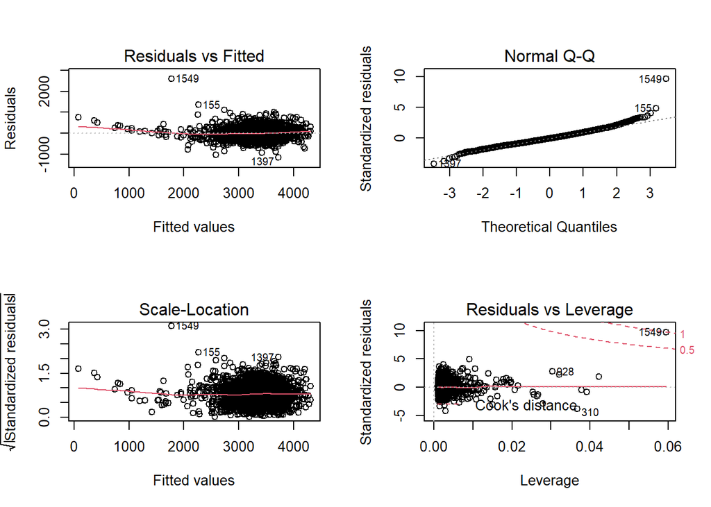

```r
par(mfrow=c(2,2))
plot(mod9)
```

Analisi sui *Leverage*

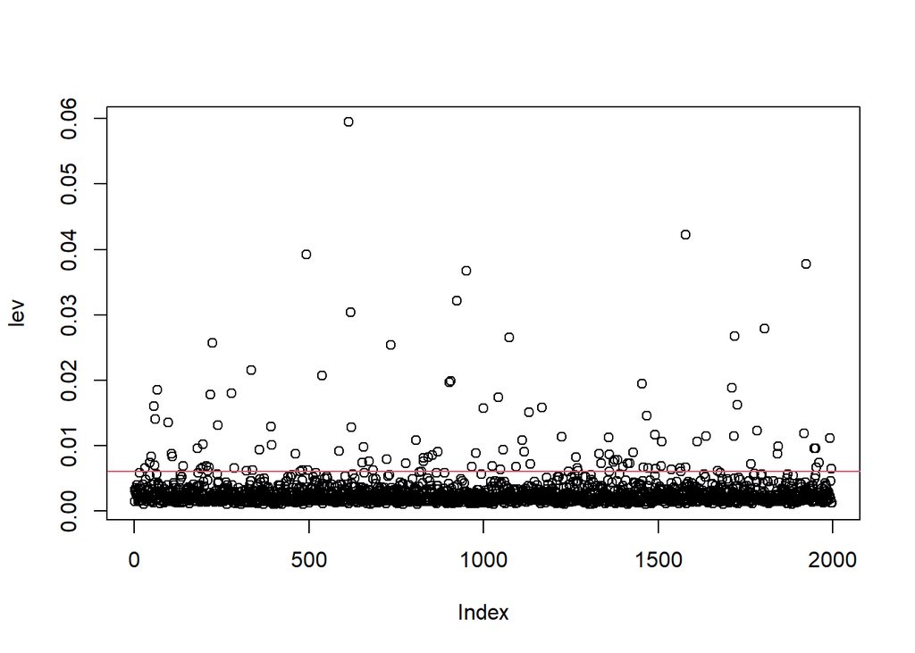

```r
lev <- hatvalues(mod9)
plot(lev)

p = sum(lev)
soglia = 2* p/n.TrainDf
abline(h=soglia,col=2)
```

Identificazione degli *outliers*

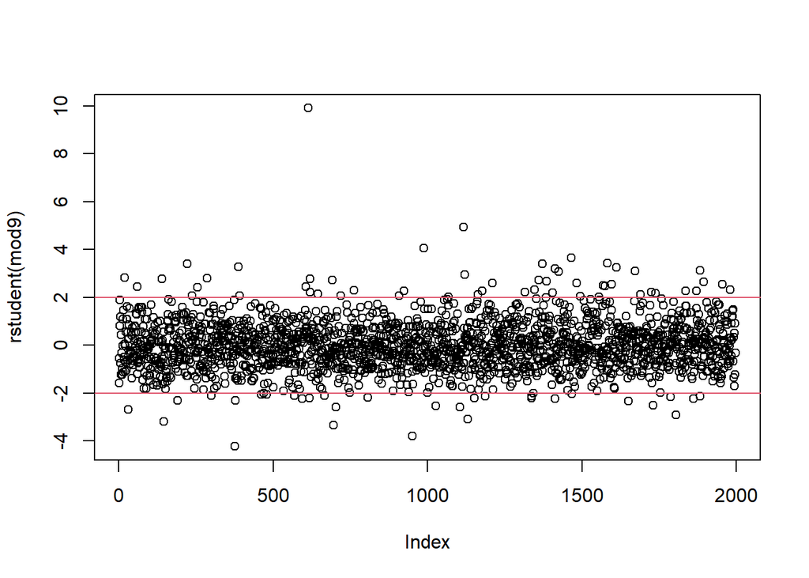

```r
plot(rstudent(mod9))
abline(h=c(-2,2), col=2)
```

Test sugli outliers con la funzione `outlierTest()` del pacchetto `car`, che di default applicherà la correzione del p-value di Bonferroni

```r
outlierTest(mod9)
```

```
##      rstudent unadjusted p-value Bonferroni p
## 1549 9.913291         1.2078e-22   2.4131e-19
## 155  4.932744         8.7811e-07   1.7545e-03
```

Le uniche 2 osservazioni classificate come *outliers* sono la 1549 e la 155.

Distanza di Cook

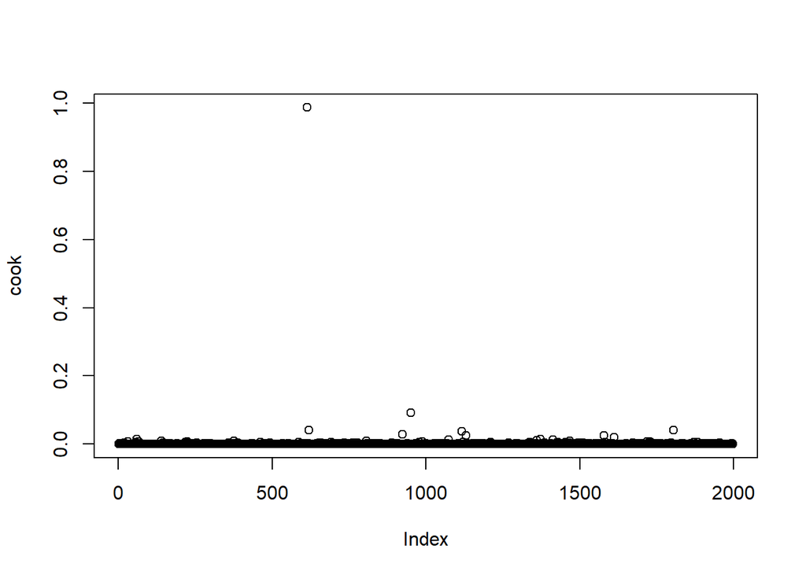

```r
cook <- cooks.distance(mod9)
plot(cook)
```

La distanza di Cook massima raggiunta è:

```r
max(cook)
```

```
## [1] 0.9871697
```

Test sui residui

Eseguo il Breusch-Pagan test sui residui per saggiare l’ipotesi di *omoschedasticità*

```r
library(lmtest)
bptest(mod9)
```

```
##
##  studentized Breusch-Pagan test
##
## data:  mod9
## BP = 100.67, df = 5, p-value < 2.2e-16
```

*Si rifiuta l’ipotesi nulla di omoschedasticità* in favore dell’ipotesi alternativa **eteroschedasticità**.

Eseguo il Durbin-Watson test per saggiare *l’ipotesi di non correlazione tra i residui*

```r
dwtest(mod9)
```

```
##
##  Durbin-Watson test
##
## data:  mod9
## DW = 2.0093, p-value = 0.5816
## alternative hypothesis: true autocorrelation is greater than 0
```

**Non si rifiuta l’ipotesi nulla**, i residui non sono autocorrelati.

Eseguo lo Shapiro-Wilk test per saggiare l’ ipotesi che i residui siano normalmente distribuiti

```r
shapiro.test(residuals(mod9))
```

```
##
##  Shapiro-Wilk normality test
##
## data:  residuals(mod9)
## W = 0.97277, p-value < 2.2e-16
```

**Si rifiuta l’ipotesi nulla di normalità.**

Rappresentazione grafica della funzione di densità dei residui

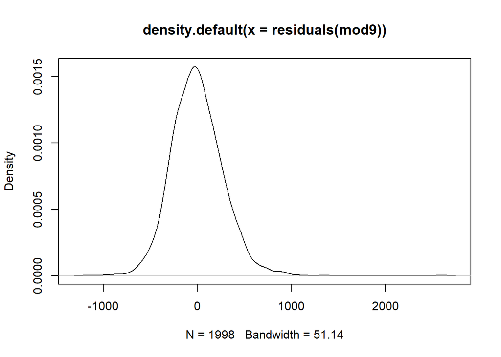

```r
plot(density(residuals(mod9)))
```

# 12 Quanto ti sembra buono il modello per fare previsioni?

Per valutare la bontà del modello nel fare previsioni mi avvarrò del *MSE*. In statistica, l’errore quadratico medio (in inglese Mean Squared Error, MSE) indica la discrepanza quadratica media fra i valori dei dati osservati ed i valori dei dati stimati. La sua radice quadrata fornisce un ulteriore indice statistico, la cosiddetta radice dell’errore quadratico medio (in inglese root-mean-square error, RMSE oppure Root Mean Square Deviation, RMSD). Corrisponde, in italiano, alla varianza interna data dal rapporto fra la devianza interna (o devianza entro i gruppi) e la numerosità totale. L’RMSE può essere anche calcolato come deviazione standard degli scarti. [Fonte Wikipedia](https://it.wikipedia.org/wiki/Errore_quadratico_medio)

Creo una colonna che riempirò con i valori di peso predetti in base ai valori delle variabili contenuti nel dataframe test_df per poi calcolare MSE

```r
previsioniDftest <- predict(mod9, test_df)

test_df$Previsione <- previsioniDftest
```

Calcolo MSE

```r
MSE <- mean((test_df$Peso - test_df$Previsione)^2)
MSE
```

```
## [1] 72707.79
```

Calcolo RMSE

```r
RMSE <- sqrt(MSE)
RMSE
```

```
## [1] 269.6438
```

# 13 Fai la tua migliore previsione per il peso di una neonata, considerato che la madre è alla terza gravidanza e partorirà alla 39esima settimana. Niente misure dall’ecografia.

## 13.1 Per effettuare la previsione stimerò un nuovo modello (mod10) nel quale andrò ad inserire le stesse variabili esplicative presenti nel mod9 scelto precedentemente, con la differenza che il mod10 verrà addestrato con tutto il dataframe e non con solo l’80% come per il mod9.

### 13.1.1 mod 10

```r
mod10 <- lm(formula = Peso ~ N.gravidanze + Gestazione + Lunghezza + Cranio +
              Sesso, data = newDf)

summary(mod10)
```

```
##
## Call:
## lm(formula = Peso ~ N.gravidanze + Gestazione + Lunghezza + Cranio +
##     Sesso, data = newDf)
##
## Residuals:
##      Min       1Q   Median       3Q      Max
## -1149.37  -180.98   -15.57   163.69  2639.09
##
## Coefficients:
##                Estimate Std. Error t value Pr(>|t|)
## (Intercept)  -6681.7251   135.8036 -49.201  < 2e-16 ***
## N.gravidanze    12.4554     4.3416   2.869  0.00415 **
## Gestazione      32.3827     3.8008   8.520  < 2e-16 ***
## Lunghezza       10.2455     0.3008  34.059  < 2e-16 ***
## Cranio          10.5410     0.4265  24.717  < 2e-16 ***
## SessoM          77.9807    11.2111   6.956 4.47e-12 ***
## ---
## Signif. codes:  0 '***' 0.001 '**' 0.01 '*' 0.05 '.' 0.1 ' ' 1
##
## Residual standard error: 274.7 on 2492 degrees of freedom
## Multiple R-squared:  0.727,  Adjusted R-squared:  0.7265
## F-statistic:  1327 on 5 and 2492 DF,  p-value: < 2.2e-16
```

### 13.1.2 Previsione del Peso:

```r
predict_df_task7 <- data.frame(N.gravidanze = 3,
                     Gestazione = 39,
                     Lunghezza = mean(newDf$Lunghezza),
                     Cranio = mean(newDf$Cranio),
                     Sesso = "F")

predictTask7 <- predict(mod10, predict_df_task7)
predictTask7
```

```
##        1
## 3271.182
```

Come si evince dalla cella sopra il **peso** predetto per una **neonata** è di circa **3271.20 gr**

# 14 Rappresenta graficamente il modello in modo che aiuti a visualizzarlo. Se è il caso semplifica quest’ultimo.

Per riuscire a rappresentare il modello l’ho semplificato. Ora sono presenti tre variabili, una risposta e due esplicative.

Semplificazione del modello:

```r
modplot <- update(mod10,~. - N.gravidanze - Cranio - Gestazione)
summary(modplot)
```

```
##
## Call:
## lm(formula = Peso ~ Lunghezza + Sesso, data = newDf)
##
## Residuals:
##     Min      1Q  Median      3Q     Max
## -1430.2  -207.7   -23.4   186.2  3925.9
##
## Coefficients:
##               Estimate Std. Error t value Pr(>|t|)
## (Intercept) -4452.9473   119.6102 -37.229  < 2e-16 ***
## Lunghezza      15.5463     0.2435  63.833  < 2e-16 ***
## SessoM         93.3576    12.8221   7.281 4.42e-13 ***
## ---
## Signif. codes:  0 '***' 0.001 '**' 0.01 '*' 0.05 '.' 0.1 ' ' 1
##
## Residual standard error: 314.7 on 2495 degrees of freedom
## Multiple R-squared:  0.6413, Adjusted R-squared:  0.641
## F-statistic:  2230 on 2 and 2495 DF,  p-value: < 2.2e-16
```

Visualizziamo graficamente:

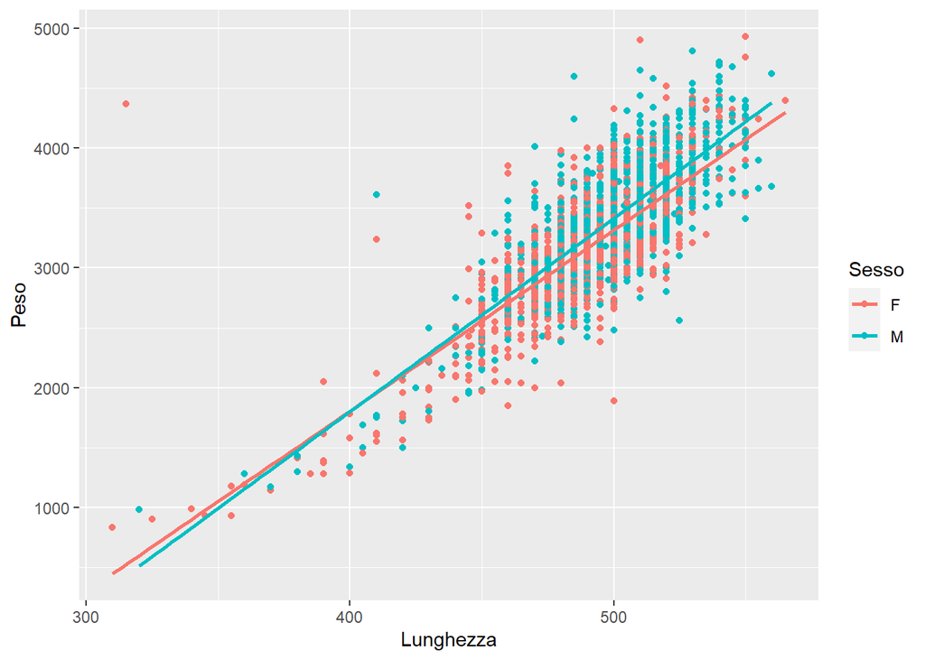

```r
ggplot(data = newDf)+
  geom_point(aes(x=Lunghezza,
                 y=Peso,
                 col= Sesso))+
  geom_smooth(aes(x=Lunghezza,
                  y=Peso,
                  col= Sesso), se=F, method = "lm")
```